# Statistics

The R Bootcamp @ Erfurt [www.therbootcamp.com](https://therbootcamp.github.io) [@therbootcamp](https://twitter.com/therbootcamp)

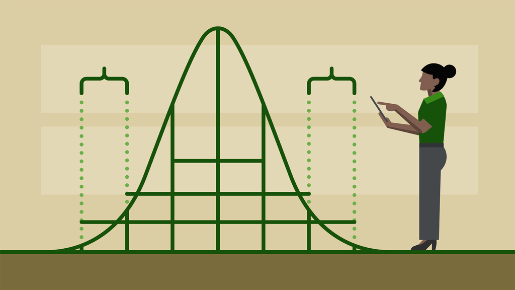

Source: https://cdn.lynda.com/course/495322/495322-636154038826424503-16x9.jpg

### Overview

In this practical you’ll do basic statistics in R. By the end of this practical you will know how to:

1. Calculate basic descriptive statistics using `mean()`, `median()`, `table()`.
2. Conduct 1 and 2 sample hypothesis tests with `t.test()`, `cor.test()`
3. Calculate regression analyses with `glm()` and `lm()`
4. Explore statistical objects with `names()`, `summary()`, `print()`, `predict()`
5. Use sampling functions such as `rnorm()` to conduct simulations

### Packages

| Package | Installation |
| --- | --- |
| `tidyverse` | `install.packages("tidyverse")` |
| `lubridate` | `install.packages("lubridate")` |
| `broom` | `install.packages("broom")` |
| `rsq` | `install.packages("rsq")` |

### Datasets

```r
library(tidyverse)
house <- read_csv("../_data/day_1/kc_house_data.csv")
```

| File | Rows | Columns | Description | Source |
| --- | --- | --- | --- | --- |
| `kc_house_data.csv` | 21613 | 21 | House sale prices for King County between May 2014 and May 2015. | [Kaggle: House Sales Prediction](https://www.kaggle.com/harlfoxem/housesalesprediction/home) |

### Glossary

*Descriptive Statistics*

| Function | Description |
| --- | --- |
| `table()` | Frequency table |
| `mean(), median(), mode()` | Measures of central tendency |
| `sd(), range(), var()` | Measures of variability |
| `max(), min()` | Extreme values |
| `summary()` | Several summary statistics |

*Statistical Tests*

| Function | Hypothesis Test |
| --- | --- |
| `t.test()` | One and two sample t-test |
| `cor.test()` | Correlation test |
| `glm()`, `lm()` | Generalized linear model and linear model |

*Sampling Functions*

| Function | Description | Additional Help |
| --- | --- | --- |
| `sample()` | Draw a random sample of values from a vector | `?sample` |
| `rnorm()` | Draw random values from a Normal distribution | `?rnorm()` |
| `runif` | Draw random values from a Uniform distribution | `?runif()` |

### Example Code

```r
# -----------------------------------------------
# Examples of hypothesis tests on the diamonds
# ------------------------------------------------
library(tidyverse)
library(broom)
library(rsq)

# First few rows of the diamonds data

diamonds

# -----
# Descriptive statistics
# -----

mean(diamonds$carat)   # What is the mean carat?
median(diamonds$price)   # What is the median price?
max(diamonds$depth)    # What is the maximum depth?
table(diamonds$color)    # How many observations for each color?

# -----
# 1-sample hypothesis test
# -----

# Q: Is the mean carat of diamonds different from .50?

htest_A <- t.test(x = diamonds$carat,     # The data
                  alternative = "two.sided",  # Two-sided test
                  mu = 0.5)                   # The null hyopthesis

htest_A            # Print result
names(htest_A)     # See all attributes in object
htest_A$statistic  # Get just the test statistic
htest_A$p.value    # Get the p-value
htest_A$conf.int   # Get a confidence interval

# -----
# 2-sample hypothesis test
# -----

# Q: Is there a difference in the carats of color = E and color = I diamonds?

htest_B <- t.test(formula = carat ~ color,     # DV ~ IV
                   alternative = "two.sided",  # Two-sided test
                   data = diamonds,         # The data
                   subset = color %in% c("E", "I")) # Compare Diet 1 and Diet 2

htest_B  # Print result

# -----
# Correlation test
# ------

# Q: Is there a correlation between carat and price?

htest_C <- cor.test(formula = ~ carat + price,
                    data = diamonds)

htest_C

# A: Yes. r = 0.92, t(53938) = 551.51, p < .001

# -----
# Regression
# ------

# Q: Create regression equation predicting price by carat, depth, table, and x

price_glm <- glm(formula = price ~ carat + depth + table + x,
                  data = diamonds)

# Print coefficients
price_glm$coefficients

# Tidy version
tidy(price_glm)

# Extract R-Squared
rsq(price_glm)

# -----
# Simulation
# ------

# 100 random samples from a normal distribution with mean = 0, sd = 1
samp_A <- rnorm(n = 100, mean = 0, sd = 1)

# 100 random samples from a Uniform distribution with bounds at 0, 10
samp_B <- runif(n = 100, min = 0, max = 10)

# Calculate descriptives
mean(samp_A)
sd(samp_A)

mean(samp_B)
sd(samp_B)

# Combine samples (plus tw new ones) in a tibble

my_sim <- tibble(A = samp_A,
                 B = samp_B,
                 C = rnorm(n = 100, mean = 0, sd = 1),
                 error = rnorm(n = 100, mean = 5, sd = 10))

# Add y, a linear function of A and B to my_sim
my_sim <- my_sim %>%
  mutate(y = 3 * A -8 * B + error)

# Regress y on A, B and C
my_glm <- glm(y ~ A + B + C,
              data = my_sim)

# Look at results!
tidy(my_glm)
```

# Tasks

### Getting setup

A. Open your R project. It should already have the folders `1_Data` and `2_Code`. Make sure that all of the data files listed above are contained in the folder

```r
# Done!
```

B. Open a new R script and save it as a new file called `statistics_practical.R` in the `2_Code` folder. At the top of the script, using comments, write your name and the date. The, load the set of packages listed above with `library()`.

```r
library(tidyverse)
library(broom)
library(rsq)
```

C. For this practical, we’ll use the `kc_house_data.csv` data. This dataset contains house sale prices for King County, Washington. It includes homes sold between May 2014 and May 2015. Using the following template, load the data into R and store it as a new object called `kc_house`.

```r
kc_house <- read_csv(file = "1_Data/kc_house_data.csv")
```

C. Using `print()`, `summary()`, `head()` and `skim()`, explore the data to make sure it was loaded correctly.

```r
kc_house
```

```
# A tibble: 21,613 x 21
   id         date                  price bedrooms bathrooms sqft_living
   <chr>      <dttm>                <dbl>    <int>     <dbl>       <int>
 1 7129300520 2014-10-13 00:00:00  221900        3      1           1180
 2 6414100192 2014-12-09 00:00:00  538000        3      2.25        2570
 3 5631500400 2015-02-25 00:00:00  180000        2      1            770
 4 2487200875 2014-12-09 00:00:00  604000        4      3           1960
 5 1954400510 2015-02-18 00:00:00  510000        3      2           1680
 6 7237550310 2014-05-12 00:00:00 1225000        4      4.5         5420
 7 1321400060 2014-06-27 00:00:00  257500        3      2.25        1715
 8 2008000270 2015-01-15 00:00:00  291850        3      1.5         1060
 9 2414600126 2015-04-15 00:00:00  229500        3      1           1780
10 3793500160 2015-03-12 00:00:00  323000        3      2.5         1890
# ... with 21,603 more rows, and 15 more variables: sqft_lot <int>,
#   floors <dbl>, waterfront <int>, view <int>, condition <int>,
#   grade <int>, sqft_above <int>, sqft_basement <int>, yr_built <int>,
#   yr_renovated <int>, zipcode <int>, lat <dbl>, long <dbl>,
#   sqft_living15 <int>, sqft_lot15 <int>
```

### Descriptive statistics

1. What was the mean price (`price`) of all houses?

```r
mean(kc_house$price)
```

```
[1] 540088.1
```

2. What was the median price (`price`) of all houses?

```r
median(kc_house$price)
```

```
[1] 450000
```

3. What was the standard deviation price (`price`) of all houses?

```r
sd(kc_house$price)
```

```
[1] 367127.2
```

4. What were the minimum and maximum prices? Try using `min()`, `max()`, and `range()`

```r
range(kc_house$price)
```

```
[1]   75000 7700000
```

5. How many houses were on the waterfront (`waterfront`) and how many were not? (Hint: use `table()`)

```r
table(kc_house$waterfront)
```

```
    0     1
21450   163
```

### T tests with t.test()

6. Do houses on the waterfront sell for more than those not on the waterfront? Answer this by creating an object called `water_htest` which contains the result of the appropriate t-test using `t.test()`. Use the following template

```r
water_htest <- t.test(formula = XX ~ XX,
                      data = XX)
```

```r
water_htest <- t.test(formula = price ~ waterfront,
                      data = kc_house)
```

- Print your `water_htest` object to see summary results

```r
water_htest
```

```
    Welch Two Sample t-test

data:  price by waterfront
t = -12.876, df = 162.23, p-value < 2.2e-16
alternative hypothesis: true difference in means is not equal to 0
95 percent confidence interval:
 -1303661.6  -956963.3
sample estimates:
mean in group 0 mean in group 1
       531563.6       1661876.0
```

- Apply the `summary()` function to `water_htest`. Do you see anything new or important?

```r
summary(water_htest)
```

```
            Length Class  Mode
statistic   1      -none- numeric
parameter   1      -none- numeric
p.value     1      -none- numeric
conf.int    2      -none- numeric
estimate    2      -none- numeric
null.value  1      -none- numeric
alternative 1      -none- character
method      1      -none- character
data.name   1      -none- character
```

- Look at the names of the `water_htest` with `names()`. What are the named elements of the object?

```r
names(water_htest)
```

```
[1] "statistic"   "parameter"   "p.value"     "conf.int"    "estimate"
[6] "null.value"  "alternative" "method"      "data.name"
```

- Using the `$` operator, print the exact test statistic of the t-test.

```r
water_htest$statistic
```

```
        t
-12.87588
```

- Again using the `$` operator, print the exact p-value of the test.

```r
water_htest$p.value
```

```
[1] 1.379112e-26
```

- Use the `tidy()` function to return a dataframe containing the main results of the test.

```r
tidy(water_htest)
```

```
  estimate estimate1 estimate2 statistic      p.value parameter conf.low
1 -1130312  531563.6   1661876 -12.87588 1.379112e-26   162.229 -1303662
  conf.high                  method alternative
1 -956963.3 Welch Two Sample t-test   two.sided
```

7. Do houses on the waterfront also tend to have more (or less) living space (`sqft_living`)? Answer this by conducting the appropriate t-test and going through the same steps you did in the previous question

```r
water2_htest <- t.test(formula = sqft_living ~ waterfront,
                      data = kc_house)

water2_htest
```

```
    Welch Two Sample t-test

data:  sqft_living by waterfront
t = -8.7506, df = 162.78, p-value = 2.569e-15
alternative hypothesis: true difference in means is not equal to 0
95 percent confidence interval:
 -1350.7971  -853.4012
sample estimates:
mean in group 0 mean in group 1
       2071.588        3173.687
```

```r
# ...
```

### Correlation tests with cor.test()

8. Do newer houses tend to sell for more than older houses? Answer this by creating an object called `time_htest` which contains the result of the appropriate correlation test using `cor.test()`. Use the following template:

```r
# Note: cor.terst() is the only function (we know of)
#  that uses formulas in the strange format
#   formula = ~ X + Y instead of formula = Y ~ X

time_htest <- cor.test(formula = ~ XX + XX,
                       data = XX)
```

```r
time_htest <- cor.test(formula = ~ yr_built + price,
                       data = kc_house)
```

- Print your `time_htest` object to see summary results

```r
time_htest
```

```
    Pearson's product-moment correlation

data:  yr_built and price
t = 7.9517, df = 21611, p-value = 1.93e-15
alternative hypothesis: true correlation is not equal to 0
95 percent confidence interval:
 0.04070886 0.06729506
sample estimates:
       cor
0.05401153
```

- Apply the `summary()` function to `time_htest`. Do you see anything new or important?

```r
summary(time_htest)
```

```
            Length Class  Mode
statistic   1      -none- numeric
parameter   1      -none- numeric
p.value     1      -none- numeric
estimate    1      -none- numeric
null.value  1      -none- numeric
alternative 1      -none- character
method      1      -none- character
data.name   1      -none- character
conf.int    2      -none- numeric
```

- Look at the names of the `time_htest` with `names()`. What are the named elements of the object?

```r
names(time_htest)
```

```
[1] "statistic"   "parameter"   "p.value"     "estimate"    "null.value"
[6] "alternative" "method"      "data.name"   "conf.int"
```

- Using the `$` operator, print the exact correlation of the test.

```r
time_htest$estimate
```

```
       cor
0.05401153
```

- Again using the `$` operator, print the exact p-value of the test.

```r
time_htest$p.value
```

```
[1] 1.929873e-15
```

- Use the `tidy()` function to return a dataframe containing the main results of the test.

```r
tidy(time_htest)
```

```
    estimate statistic      p.value parameter   conf.low  conf.high
1 0.05401153   7.95167 1.929873e-15     21611 0.04070886 0.06729506
                                method alternative
1 Pearson's product-moment correlation   two.sided
```

- Use the `rsq()` function to obtain the R-squared value.

```r
# Actually it doesn't work!

#rsq(time_htest)
```

9. Do houses in in better overall condition `condition` tend to sell at higher prices than those in worse condition? Answer this by conducting the appropriate correlation test and going through the same steps you did in the previous question.

```r
condition_htest <- cor.test(formula = ~ condition + price,
                            data = kc_house)

condition_htest
```

```
    Pearson's product-moment correlation

data:  condition and price
t = 5.349, df = 21611, p-value = 8.936e-08
alternative hypothesis: true correlation is not equal to 0
95 percent confidence interval:
 0.02304097 0.04966970
sample estimates:
       cor
0.03636179
```

```r
# ...
```

### Linear Regression with lm() and glm()

10. In the previous question, you used a correlation test to see if newer houses tend to sell for more than older houses. Now let’s repeat the same analysis using a regression analysis with `lm()`. Do to this, use the following template:

```r
time_lm <- lm(formula = XX ~ XX,
                 data = XX)
```

```r
time_lm <- lm(formula = price ~ yr_built,
                 data = kc_house)
```

- Print your `time_lm` object to see the main results.

```r
time_lm
```

```
Call:
lm(formula = price ~ yr_built, data = kc_house)

Coefficients:
(Intercept)     yr_built
  -790477.9        675.1
```

- Use the `tidy()` function (from the `broom` package) to return a dataframe containing the main results of the test.

```r
tidy(time_lm)
```

```
         term     estimate    std.error statistic      p.value
1 (Intercept) -790477.8729 167350.23419 -4.723494 2.332828e-06
2    yr_built     675.0698     84.89661  7.951670 1.929873e-15
```

- How does the p-value of this test compare to what you got in the previous question when you used `cor.test()`?

```r
# The same!
```

11. Which of the variables `bedrooms`, `bathrooms`, and `sqft_living` predict housing price? Answer this by conducting the appropriate regression analysis using `lm()` and assigning the result to an object `price_lm`. Use the following template:

```r
price_lm <- lm(formula = XX ~ XX + XX + XX,
                 data = XX)
```

```r
price_lm <- lm(formula = price ~ bedrooms + bathrooms + sqft_living,
                 data = kc_house)
```

- Print your `price_lm` object to see the main results.

```r
price_lm
```

```
Call:
lm(formula = price ~ bedrooms + bathrooms + sqft_living, data = kc_house)

Coefficients:
(Intercept)     bedrooms    bathrooms  sqft_living
    74847.1     -57860.9       7932.7        309.4
```

- Apply the `summary()` function to `price_lm`. Do you see anything new or important?

```r
summary(price_lm)
```

```
Call:
lm(formula = price ~ bedrooms + bathrooms + sqft_living, data = kc_house)

Residuals:
     Min       1Q   Median       3Q      Max
-1642456  -144268   -22821   102461  4180678

Coefficients:
              Estimate Std. Error t value Pr(>|t|)
(Intercept)  74847.141   6913.667   10.83   <2e-16 ***
bedrooms    -57860.894   2334.607  -24.78   <2e-16 ***
bathrooms     7932.712   3510.556    2.26   0.0239 *
sqft_living    309.392      3.087  100.23   <2e-16 ***
---
Signif. codes:  0 '***' 0.001 '**' 0.01 '*' 0.05 '.' 0.1 ' ' 1

Residual standard error: 257800 on 21609 degrees of freedom
Multiple R-squared:  0.5069,    Adjusted R-squared:  0.5069
F-statistic:  7405 on 3 and 21609 DF,  p-value: < 2.2e-16
```

- Look at the names of the `price_lm` with `names()`. What are the named elements of the object?

```r
names(price_lm)
```

```
 [1] "coefficients"  "residuals"     "effects"       "rank"
 [5] "fitted.values" "assign"        "qr"            "df.residual"
 [9] "xlevels"       "call"          "terms"         "model"
```

- Using the `$` operator, print a vector of the estimated coefficients of the analysis.

```r
price_lm$coefficients
```

```
(Intercept)    bedrooms   bathrooms sqft_living
 74847.1408 -57860.8943   7932.7122    309.3924
```

- Use the `tidy()` function (from the `broom` package) to return a dataframe containing the main results of the test.

```r
tidy(price_lm)
```

```
         term    estimate   std.error  statistic       p.value
1 (Intercept)  74847.1408 6913.666912  10.825969  3.046344e-27
2    bedrooms -57860.8943 2334.607078 -24.783997 9.812099e-134
3   bathrooms   7932.7122 3510.555931   2.259674  2.385140e-02
4 sqft_living    309.3924    3.086779 100.231460  0.000000e+00
```

- Use the `rsq()` function (from the `rsq` package) to obtain the R-squared value. Does this match what you saw in your previous outputs?

```r
rsq(price_lm)
```

```
[1] 0.5069198
```

12. Using the following template, create a new model called `everything_lm` that predicts housing prices based on *all* predictors in `kc_house` *except* for `id` and `date` (`id` is meaningless and date shouldn’t matter). Use the following template. Note that to include all predictors, we’ll use the `formula = y ~.` shortcut. We’ll also remove id and date from the dataset using `select()` before running the analysis.

```r
everything_lm <- lm(formula = XX ~.,
                    data = kc_house %>%
                             select(-id, -date))
```

```r
everything_lm <- lm(formula = price ~.,
                    data = kc_house %>%
                             select(-id, -date))
```

- Print your `everything_lm` object to see the main results.

```r
everything_lm
```

```
Call:
lm(formula = price ~ ., data = kc_house %>% select(-id, -date))

Coefficients:
  (Intercept)       bedrooms      bathrooms    sqft_living       sqft_lot
    6.690e+06     -3.577e+04      4.114e+04      1.501e+02      1.286e-01
       floors     waterfront           view      condition          grade
    6.690e+03      5.830e+05      5.287e+04      2.639e+04      9.589e+04
   sqft_above  sqft_basement       yr_built   yr_renovated        zipcode
    3.113e+01             NA     -2.620e+03      1.981e+01     -5.824e+02
          lat           long  sqft_living15     sqft_lot15
    6.027e+05     -2.147e+05      2.168e+01     -3.826e-01
```

- Apply the `summary()` function to `everything_lm`. Do you see anything new or important?

```r
summary(everything_lm)
```

```
Call:
lm(formula = price ~ ., data = kc_house %>% select(-id, -date))

Residuals:
     Min       1Q   Median       3Q      Max
-1291725   -99229    -9739    77583  4333222

Coefficients: (1 not defined because of singularities)
                Estimate Std. Error t value Pr(>|t|)
(Intercept)    6.690e+06  2.931e+06   2.282  0.02249 *
bedrooms      -3.577e+04  1.892e+03 -18.906  < 2e-16 ***
bathrooms      4.114e+04  3.254e+03  12.645  < 2e-16 ***
sqft_living    1.501e+02  4.385e+00  34.227  < 2e-16 ***
sqft_lot       1.286e-01  4.792e-02   2.683  0.00729 **
floors         6.690e+03  3.596e+03   1.860  0.06285 .
waterfront     5.830e+05  1.736e+04  33.580  < 2e-16 ***
view           5.287e+04  2.140e+03  24.705  < 2e-16 ***
condition      2.639e+04  2.351e+03  11.221  < 2e-16 ***
grade          9.589e+04  2.153e+03  44.542  < 2e-16 ***
sqft_above     3.113e+01  4.360e+00   7.139 9.71e-13 ***
sqft_basement         NA         NA      NA       NA
yr_built      -2.620e+03  7.266e+01 -36.062  < 2e-16 ***
yr_renovated   1.981e+01  3.656e+00   5.420 6.03e-08 ***
zipcode       -5.824e+02  3.299e+01 -17.657  < 2e-16 ***
lat            6.027e+05  1.073e+04  56.149  < 2e-16 ***
long          -2.147e+05  1.313e+04 -16.349  < 2e-16 ***
sqft_living15  2.168e+01  3.448e+00   6.289 3.26e-10 ***
sqft_lot15    -3.826e-01  7.327e-02  -5.222 1.78e-07 ***
---
Signif. codes:  0 '***' 0.001 '**' 0.01 '*' 0.05 '.' 0.1 ' ' 1

Residual standard error: 201200 on 21595 degrees of freedom
Multiple R-squared:  0.6997,    Adjusted R-squared:  0.6995
F-statistic:  2960 on 17 and 21595 DF,  p-value: < 2.2e-16
```

- Using the `$` operator, print a vector of the estimated coefficients of the analysis. Are the beta values for bedrooms, bathrooms, and sqft_living different from what you got in your previous analysis `price_lm`?

```r
everything_lm$coefficients
```

```
  (Intercept)      bedrooms     bathrooms   sqft_living      sqft_lot
 6.690325e+06 -3.576654e+04  4.114428e+04  1.501005e+02  1.285979e-01
       floors    waterfront          view     condition         grade
 6.689550e+03  5.829605e+05  5.287094e+04  2.638565e+04  9.589045e+04
   sqft_above sqft_basement      yr_built  yr_renovated       zipcode
 3.112758e+01            NA -2.620223e+03  1.981258e+01 -5.824199e+02
          lat          long sqft_living15    sqft_lot15
 6.027482e+05 -2.147298e+05  2.168140e+01 -3.826418e-01
```

- Use the `tidy()` function to return a dataframe containing the main results of the test.

```r
tidy(everything_lm)
```

```
            term      estimate    std.error  statistic       p.value
1    (Intercept)  6.690325e+06 2.931485e+06   2.282231  2.248541e-02
2       bedrooms -3.576654e+04 1.891843e+03 -18.905663  4.460096e-79
3      bathrooms  4.114428e+04 3.253678e+03  12.645469  1.596998e-36
4    sqft_living  1.501005e+02 4.385409e+00  34.227254 4.466373e-250
5       sqft_lot  1.285979e-01 4.792237e-02   2.683462  7.291971e-03
6         floors  6.689550e+03 3.595859e+03   1.860348  6.284986e-02
7     waterfront  5.829605e+05 1.736010e+04  33.580488 5.007658e-241
8           view  5.287094e+04 2.140055e+03  24.705418 6.538058e-133
9      condition  2.638565e+04 2.351461e+03  11.220959  3.874277e-29
10         grade  9.589045e+04 2.152789e+03  44.542422  0.000000e+00
11    sqft_above  3.112758e+01 4.360319e+00   7.138831  9.710987e-13
12      yr_built -2.620223e+03 7.265914e+01 -36.061853 1.389078e-276
13  yr_renovated  1.981258e+01 3.655592e+00   5.419802  6.030379e-08
14       zipcode -5.824199e+02 3.298581e+01 -17.656677  2.775354e-69
15           lat  6.027482e+05 1.073472e+04  56.149395  0.000000e+00
16          long -2.147298e+05 1.313390e+04 -16.349280  1.005905e-59
17 sqft_living15  2.168140e+01 3.447721e+00   6.288618  3.264445e-10
18    sqft_lot15 -3.826418e-01 7.326917e-02  -5.222413  1.782435e-07
```

- Use the `rsq()` function (from the `rsq` package) to obtain the R-squared value. How does this R-squared value compare to what you got in your previous regression `price_lm`?

```r
rsq(everything_lm)
```

```
[1] 0.6997472
```

13. How well did the `everything_lm` model fit the actual housing prices? We can answer this by calculating the average difference between the fitted values and the true values directly. Using the following template, make this calculation. What do you find is the mean absolute difference between the fitted housing prices and the true prices?

```r
# True housing prices
prices_true <- kc_house$XX

# Model fits (fitted.values)
prices_fitted <- everything_lm$XX

# Calculate absolute error between fitted and true values
abs_error <- abs(XX - XX)

# Calculate mean absolute error
mae <- mean(XX)

# Print the result!
mae
```

```r
# True housing prices
prices_true <- kc_house$price

# Model fits (fitted.values)
prices_fitted <- everything_lm$fitted.values

# Calculate absolute error between fitted and true values
abs_error <- abs(prices_true - prices_fitted)

# Calculate mean absolute error
mae <- mean(abs_error)

# Print the result!
mae
```

```
[1] 125922.6
```

14. Using the following template, create a scatterplot showing the relationship between the fitted values of the `everything_lm` object and the true prices.

```r
# Create dataframe containing fitted and true prices
prices_results <- tibble(truth = XX,
                         fitted = XX)

# Create scatterplot
ggplot(data = prices_results,
       aes(x = fitted, y = truth)) +
  geom_point(alpha = .1) +
  geom_smooth(method = 'lm') +
  labs(title = "Fitted versus Predicted housing prices",
       subtitle = paste0("Mean Absolute Error = ", mae),
       caption = "Source: King County housing price Kaggle dataset",
       x = "Fitted housing price values",
       y = 'True values') +
  theme_minimal()
```

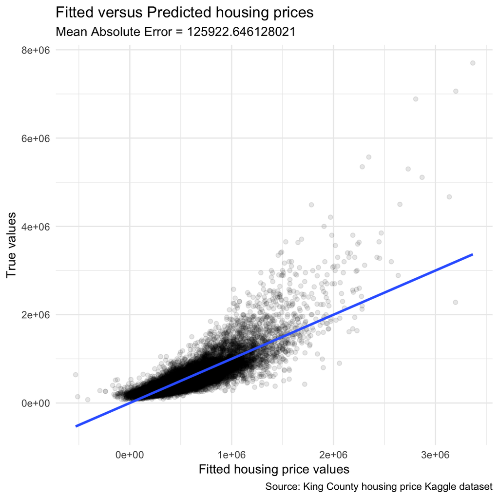

```r
# Create dataframe containing fitted and true prices
prices_results <- tibble(truth = prices_true,
                         fitted = prices_fitted)

# Create scatterplot
ggplot(data = prices_results,
       aes(x = fitted, y = truth)) +
  geom_point(alpha = .1) +
  geom_smooth(method = 'lm') +
  labs(title = "Fitted versus Predicted housing prices",
       subtitle = paste0("Mean Absolute Error = ", mae),
       caption = "Source: King County housing price Kaggle dataset",
       x = "Fitted housing price values",
       y = 'True values') +
  theme_minimal()
```

### Logistic regression

15. In the next set of analyses, we’ll use logistic regression to predict whether or not a house will sell for over $1,000,000. First, we’ll need to create a new binary variable in the `kc_house` called `million` that is 1 when the price is over 1 million, and 0 when it is not. Run the following code to create this new variable

```r
# Create a new binary variable called million that
#  indicates when houses sell for more than 1 million

# Note: 1e6 is a shortcut for 1000000

kc_house <- kc_house %>%
  mutate(million = price > 1e6)
```

16. Using the following template, use the `glm()` function to conduct a logistic regression to see which of the variables `bedrooms`, `bathrooms`, `floors`, `waterfront`, `yr_built` predict whether or not a house will sell for over 1 Million. Be sure to include the argument `family = 'binomial'` to tell `glm()` that we are conducting a logistic regression analysis.

```r
# Logistic regression analysis predicting which houses will sell for
#   more than 1 Million

million_glm <- glm(formula = XX ~ XX + XX + XX + XX + XX,
                   data = kc_house,
                   family = "XX")
```

```r
million_glm <- glm(formula = million ~ bedrooms + bathrooms + floors + waterfront + yr_built,
                   family = "binomial",   # Logistic regression
                   data = kc_house)
```

- Print your `million_glm` object to see the main results.

```r
million_glm
```

```
Call:  glm(formula = million ~ bedrooms + bathrooms + floors + waterfront +
    yr_built, family = "binomial", data = kc_house)

Coefficients:
(Intercept)     bedrooms    bathrooms       floors   waterfront
   27.92982      0.09524      2.04122      0.42525      3.27013
   yr_built
   -0.01867

Degrees of Freedom: 21612 Total (i.e. Null);  21607 Residual
Null Deviance:      10710
Residual Deviance: 7391     AIC: 7403
```

- Apply the `summary()` function to `million_glm`.

```r
summary(million_glm)
```

```
Call:
glm(formula = million ~ bedrooms + bathrooms + floors + waterfront +
    yr_built, family = "binomial", data = kc_house)

Deviance Residuals:
    Min       1Q   Median       3Q      Max
-3.9182  -0.3076  -0.2182  -0.1143   4.0936

Coefficients:
             Estimate Std. Error z value Pr(>|z|)
(Intercept) 27.929817   2.152211  12.977  < 2e-16 ***
bedrooms     0.095237   0.034519   2.759   0.0058 **
bathrooms    2.041219   0.054958  37.142  < 2e-16 ***
floors       0.425255   0.068982   6.165 7.06e-10 ***
waterfront   3.270126   0.211849  15.436  < 2e-16 ***
yr_built    -0.018673   0.001116 -16.736  < 2e-16 ***
---
Signif. codes:  0 '***' 0.001 '**' 0.01 '*' 0.05 '.' 0.1 ' ' 1

(Dispersion parameter for binomial family taken to be 1)

    Null deviance: 10714.3  on 21612  degrees of freedom
Residual deviance:  7391.1  on 21607  degrees of freedom
AIC: 7403.1

Number of Fisher Scoring iterations: 7
```

- Using the `$` operator, print a vector of the estimated beta values (coefficients) of the analysis.

```r
million_glm$coefficients
```

```
(Intercept)    bedrooms   bathrooms      floors  waterfront    yr_built
27.92981675  0.09523674  2.04121853  0.42525455  3.27012640 -0.01867290
```

- Use the `tidy()` function to return a dataframe containing the main results of the test.

```r
tidy(million_glm)
```

```
         term    estimate   std.error  statistic       p.value
1 (Intercept) 27.92981675 2.152211183  12.977266  1.646540e-38
2    bedrooms  0.09523674 0.034518893   2.758974  5.798308e-03
3   bathrooms  2.04121853 0.054957806  37.141558 6.000104e-302
4      floors  0.42525455 0.068982018   6.164716  7.060979e-10
5  waterfront  3.27012640 0.211848542  15.436152  9.351496e-54
6    yr_built -0.01867290 0.001115733 -16.735985  7.166189e-63
```

17. You can get the fitted probability predictions that each house will sell for more than 1 Million by accessing the vector `million_glm$fitted.values`. Using this vector, calculate the average probability that houses will sell for more than 1 Million (hint: just take the mean!)

```r
mean(million_glm$fitted.values)
```

```
[1] 0.06778328
```

- Using the following code, create a data frame showing the relationship between the fitted probability that a house sells for over 1 Million and the true probability:

```r
# Just run it!

million_fit <- tibble(pred_million = million_glm$fitted.values,
                      true_million = kc_house$million) %>%
                mutate(fitted_cut = cut(pred_million, breaks = seq(0, 1, .1))) %>%
                group_by(fitted_cut) %>%
                summarise(true_prob = mean(true_million))

million_fit
```

```
# A tibble: 10 x 2
   fitted_cut true_prob
   <fct>          <dbl>
 1 (0,0.1]       0.0231
 2 (0.1,0.2]     0.192
 3 (0.2,0.3]     0.292
 4 (0.3,0.4]     0.387
 5 (0.4,0.5]     0.562
 6 (0.5,0.6]     0.518
 7 (0.6,0.7]     0.550
 8 (0.7,0.8]     0.673
 9 (0.8,0.9]     0.574
10 (0.9,1]       0.837
```

- Now plot the results using the following code:

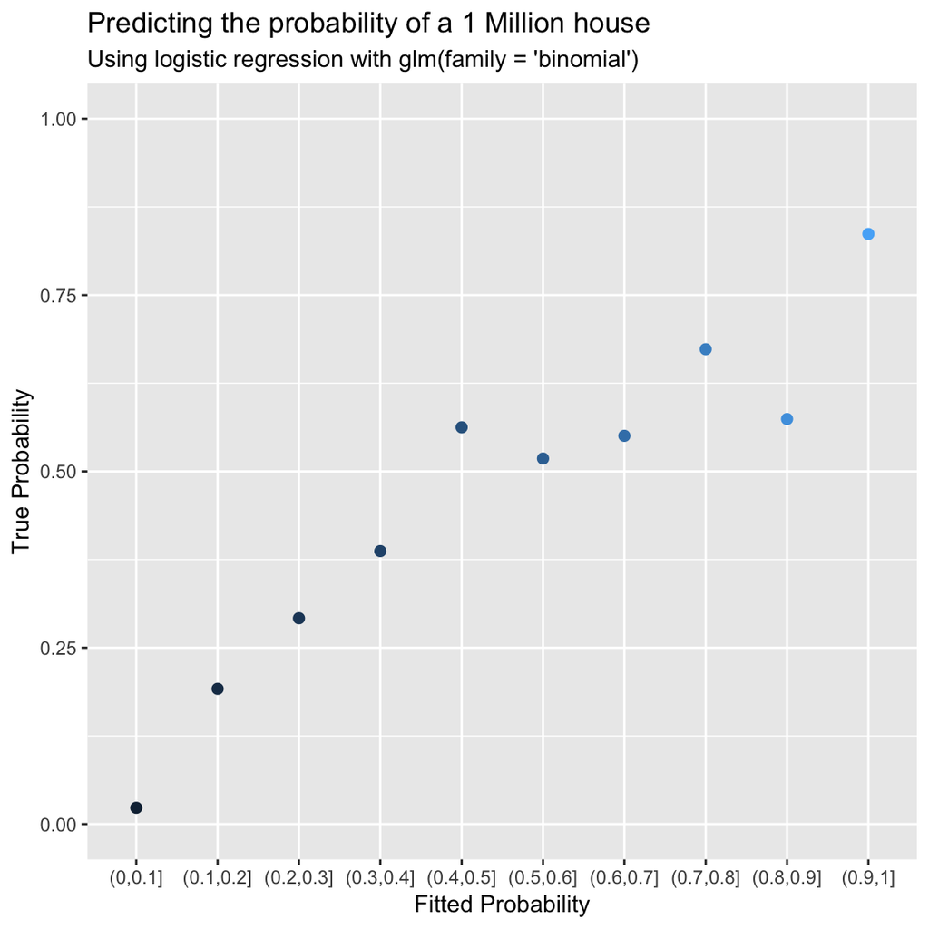

```r
# Just run it!

ggplot(million_fit,
       aes(x = fitted_cut, y = true_prob, col = as.numeric(fitted_cut))) +
  geom_point(size = 2) +
  labs(x = "Fitted Probability",
       y = "True Probability",
       title = "Predicting the probability of a 1 Million house",
       subtitle = "Using logistic regression with glm(family = 'binomial')") +
  scale_y_continuous(limits = c(0, 1)) +
  guides(col = FALSE)
```

### Transforming variables

18. In most real world datasets, distributions of housing prices are heavily skewed, where most houses sell for a small to moderate amount, and a small number of houses sell for much more. Is this the case in the `kc_house` dataset? Find out by creating a histogram of `price` with the following code:

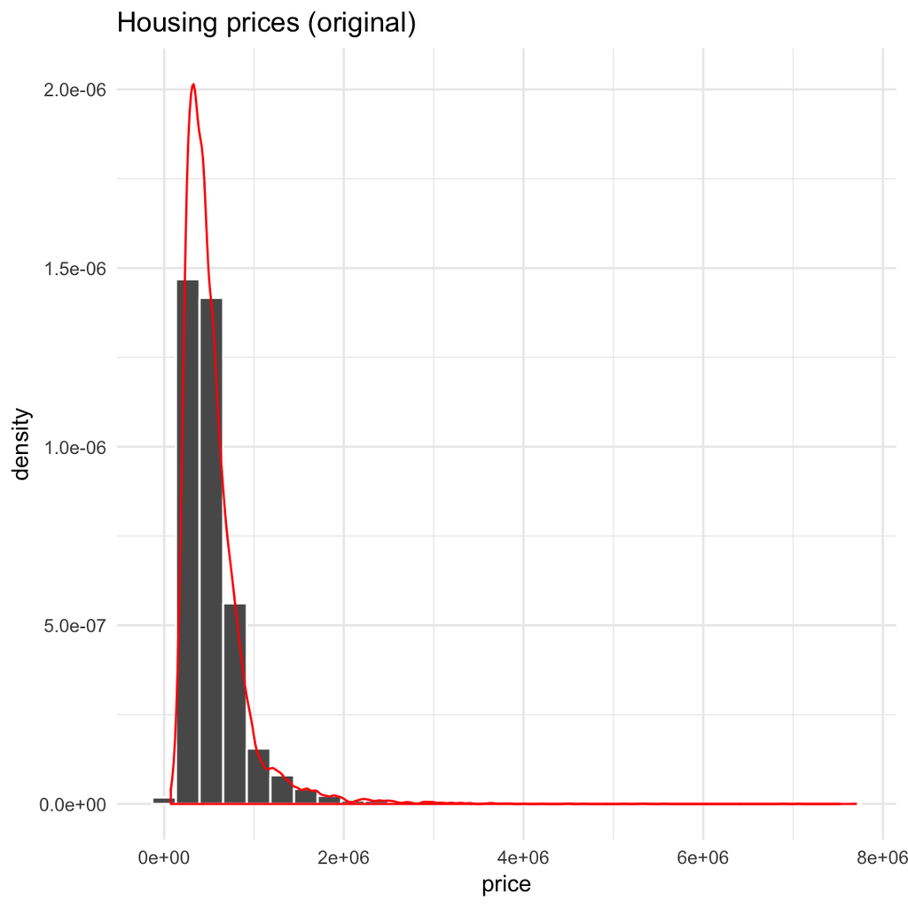

```r
# Just run it!

# Create a histogram of housing prices
ggplot(data = kc_house,
       aes(x = price, y = ..density..)) +
  geom_histogram(col = "white") +
  geom_density(col = "red") +
  theme_minimal() +
  labs(title = "Housing prices (original)")
```

19. If you find the data were heavily skewed, try looking at a histogram of the log transformed housing prices using the `log()` function

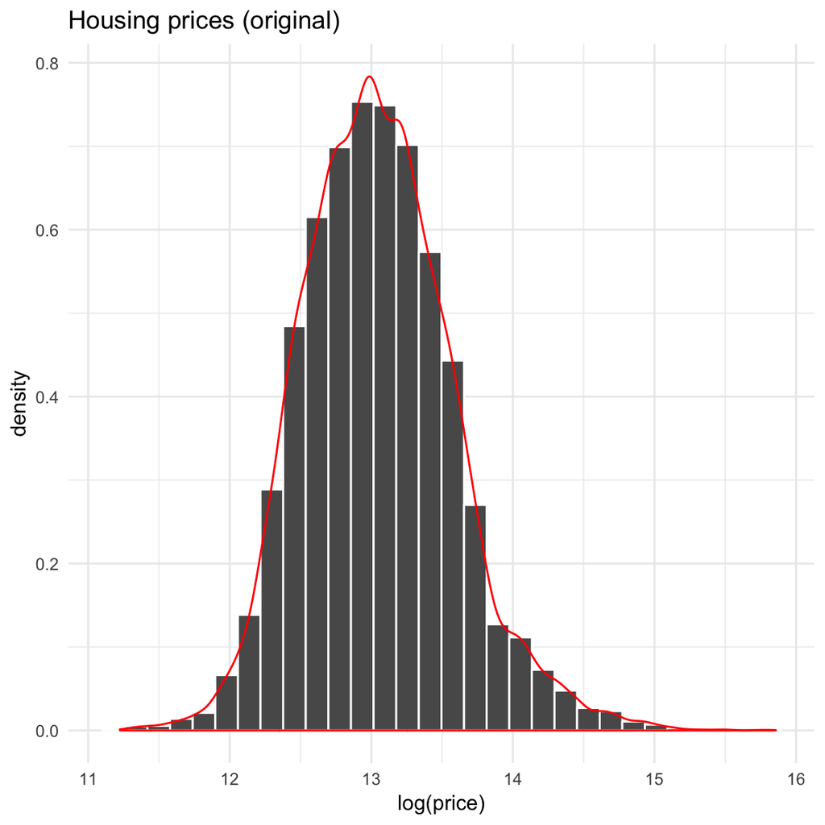

```r
# Just run it!

# Create a histogram of housing prices
ggplot(data = kc_house,
       aes(x = log(price), y = ..density..)) +
  geom_histogram(col = "white") +
  geom_density(col = "red") +
  theme_minimal() +
  labs(title = "Housing prices (original)")
```

20. Using the following code, add a new variable called `price_l` to `kc_house` that contains log–transformed prices.

```r
# Add price_l, log-transformed price, to kc_house
kc_house <- kc_house %>%
  mutate(price_l = log(price))
```

21. Now that you’ve created `price_l`, try repeating your previous regression analyses. Do you get the same results? If not, which results do you trust more?

```r
# on your own!
```

### Using predict() to predict new values

22. Your friend Donald just bought a house whose building records have been lost. She wants to know what year her house was likely built. Help Donald figure out when his house was built by conducting the appropriate regression analysis, and then using the specifics of his house to predict the year that his house was built using the `predict()` function. You know that his house is on the waterfront, has 3 bedrooms, 2 floors and has a condition of 4. The following block of code may help you!

```r
# Create regression model predicting year (yr_built)
year_lm <- lm(formula = XX ~ XX + XX + XX + XX,
              data = XX)

# Define Donald's House
DonaldsHouse <- tibble(waterfront = X,
                       bedrooms = X,
                       floors = X,
                       condition = X)

# Predict the hear of donald's house
predict(object = year_lm,
        newdata = DonaldsHouse)
```

```r
# Create regression model predicting year (yr_built)
year_lm <- lm(formula = yr_built ~ waterfront + bedrooms + floors + condition,
              data = kc_house)

# Define Donald's House
DonaldsHouse <- tibble(waterfront = 1,
                       bedrooms = 3,
                       floors = 2,
                       condition = 4)

# Predict the hear of donald's house
predict(object = year_lm,
        newdata = DonaldsHouse)
```

```
       1
1963.885
```

### Generating random samples from distributions

23. You can easily generate random samples from statistical distributions in R. To see all of them, run `?distributions`. For example, to generate samples from the well known Normal distribution, you can use `rnorm()`. Look at the help menu for `rnorm()` to see its arguments.
24. Let’s explore the `rnorm()` function. Using `rnorm()`, create a new object `samp_100` which is 100 samples from a Normal distribution with mean 10 and standard deviation 5. Print the object to see what the elements look like. What should the mean and standard deviation of this sample? be? Test it by evaluating its mean and standard deviation directly using the appropriate functions. Then, do a one-sample t-test on this sample against the null hypothesis that the true mean is 10. What are the results? Use the following code template to help!

```r
# Generate 100 samples from a Normal distribution with mean = 10 and sd = 5
samp_100 <- rnorm(n = XX, mean = XX, sd = XX)

# Print result
samp_100

# Calcultae sample mean and standard deviation.
mean(XX)
sd(XX)

t.test(x = XX,   # Vector of values
       mu = XX)  # Mean under null hypothesis
```

```r
# Generate 100 samples from a Normal distribution with mean = 10 and sd = 5
samp_100 <- rnorm(n = 100, mean = 10, sd = 5)

# Print result
samp_100
```

```
  [1]  7.7123149  0.0295536 15.4177207  1.8091445  4.8427877  9.7708274
  [7] 10.1343561 11.1991115 11.7673196 10.8825861  7.9837963 18.3583695
 [13] 22.0864481 15.7664408 14.4855380 10.8448450  9.8525495  3.1577809
 [19]  4.1783465  6.0854516  7.8272127  5.8079508 11.8415534  6.1164426
 [25] 10.4629226  9.2174843 12.7622893 13.4996237 15.8221147 12.8715114
 [31] 15.9768745  7.8619657 18.0703823  9.2978981  1.3741191  6.6422572
 [37]  3.1675480  7.1475393  1.7928087  6.7128352 12.2255039 12.0311948
 [43] 16.6516502 21.2151224  8.0239223  5.1164304 10.9439008 12.9135575
 [49] 13.4913153  6.6957224  6.8585887 11.5052704 10.9082755  8.0249644
 [55]  6.6295324  4.6254969  5.0244020  8.0361374  7.7478228  8.7272640
 [61] 14.9102524 18.1796592 10.3165647 13.5585428  4.8796974  9.3854295
 [67]  1.6344352  7.1909232 12.6420497 11.4103614 17.0717663 11.6628556
 [73]  8.1236099 13.0811984 17.3548255  6.5946889 10.9775800 15.8909203
 [79]  8.0364854 15.3454795 12.5222672 10.0226927  8.7717356 13.4319201
 [85]  3.1891194 15.2602636 11.2638745 12.0048706 10.1891494  9.4931506
 [91] 17.0967707 11.4358932 10.1487704  4.7057640 13.7424784  4.0489639
 [97] 16.9999941 10.8806999  4.4738260 10.1907790
```

```r
# Calcultae sample mean and standard deviation.
mean(samp_100)
```

```
[1] 10.16155
```

```r
sd(samp_100)
```

```
[1] 4.59164
```

```r
t.test(x = samp_100,   # Vector of values
       mu = 10)  # Mean under null hypothesis
```

```
    One Sample t-test

data:  samp_100
t = 0.35184, df = 99, p-value = 0.7257
alternative hypothesis: true mean is not equal to 10
95 percent confidence interval:
  9.250469 11.072631
sample estimates:
mean of x
 10.16155
```

25. Repeat the previous block of code several times and look at how the output changes. How do the p-values change when you keep drawing random samples?

```r
# on your own!
```

26. Change the mean under the null hypothesis to 15 instead of 10 and run the code again several times. What happens to the p-values?

```r
# on your own!
```

27. Look at the code below. As you can see, I generate 4 variables x1, x2, x3 and noise. I then create a dependent variable y that is a function of these variables. Finally, I conduct a regression analysis. *Before you run the code*, what do you expect the value of the `coefficients` of the regression equation will be? Test your prediction by running the code and exploring the `my_lm` object.

```r
# Generate independent variables
x1 <- rnorm(n = 100, mean = 10, sd = 1)
x2 <- rnorm(n = 100, mean = 20, sd = 10)
x3 <- rnorm(n = 100, mean = -5, sd = 5)

# Generate noise
noise <- rnorm(n = 100, mean = 0, sd = 1)

# Create dependent variable
y <- 3 * x1 + 2 * x2 - 5 * x3 + 100 + noise

# Combine all into a tibble
my_data <- tibble(x1, x2, x3, y)

# Calculate my_lm
my_lm <- lm(formula = y ~ x1 + x2 + x3,
              data = my_data)
```

28. Adjust the code above so that the coefficients for the regression equation will be (close to) `(Intercept) = -50`, `x1 = -3`, `x2 = 10`, `x3 = 15`

```r
# Generate independent variables
x1 <- rnorm(n = 100, mean = 10, sd = 1)
x2 <- rnorm(n = 100, mean = 20, sd = 10)
x3 <- rnorm(n = 100, mean = -5, sd = 5)

# Generate noise
noise <- rnorm(n = 100, mean = 0, sd = 1)

# Create dependent variable
y <- -3 * x1 + 10 * x2 + 15 * x3 - 50 + noise

# Combine all into a tibble
my_data <- tibble(x1, x2, x3, y)

# Calculate my_lm
my_lm <- lm(formula = y ~ x1 + x2 + x3,
              data = my_data)
```

# Additional reading

- For more advanced mixed level ANOVAs with random effects, consult the `afex` and `lmer` packages.
- To do Bayesian versions of common hypothesis tests, try using the `BayesFactor` package. [BayesFactor Guide Link](https://cran.r-project.org/web/packages/BayesFactor/vignettes/manual.html)